# Multiple and complex regression

The RMarkdown file for this lesson can be found [here](https://raw.githubusercontent.com/chrischizinski/SNR_R_Group/master/Rmd/2016-10-20-XXXX.Rmd).

This lesson will follow Chapter 6 in Quinn and Keough (2002).

Load the packages we will be using in this lesson

```r
library(RCurl)
library(tidyverse)
library(broom)
library(GGally)
library(devtools)

source_url('https://raw.githubusercontent.com/chrischizinski/SNR_R_Group/master/R/snr_r_group_functions.R')
```

## Multiple Linear regression analysis

Our previous lesson was based on regression models with a single predictor and single response variable. We can expand on these by increasing the number of predictor variables, which are called are *multiple linear regression* models. Many of the tools that we covered to assess outliers and model fit can also be used in multiple linear regression. We will not spend a lot of time going back over these in this lesson.

- Similar assumptions of the model to the simple models
- Fixed Xs, random Y

Model represented as:
$$y_i = \beta_0 + \beta_1 x_{i1} + \beta_2 x_{i2} + \dots + \beta_j x_{ij} + \dots \beta_p x_{ip} + \epsilon_i$$

Lets illustrate these models using the `lyon` data found in `chapt6` folder found in the github repository.

> Loyn (1987) selected 56 forest patches in southeastern Victoria, Australia, and related the abundance of forest birds in each patch to six predictor variables: patch area (ha), distance to nearest patch (km), distance to nearest larger patch (km), grazing stock (1 to 5 indicating light to heavy), altitude (m) and years since isolation (years).

```r
bird_abund <- read_csv(getURL('https://raw.githubusercontent.com/chrischizinski/SNR_R_Group/master/data/ExperimentalDesignData/chpt6/loyn.csv'))

bird_abund$GRAZE <- as.factor(bird_abund$GRAZE)
bird_abund$YEAR_SINCE <- 1987 - bird_abund$YR.ISOL

glimpse(bird_abund)
```

```
## Observations: 56
## Variables: 22
## $ ABUND      <dbl> 5.3, 2.0, 1.5, 17.1, 13.8, 14.1, 3.8, 2.2, 3.3, 3.0...
## $ AREA       <dbl> 0.1, 0.5, 0.5, 1.0, 1.0, 1.0, 1.0, 1.0, 1.0, 1.0, 2...
## $ YR.ISOL    <int> 1968, 1920, 1900, 1966, 1918, 1965, 1955, 1920, 196...
## $ DIST       <int> 39, 234, 104, 66, 246, 234, 467, 284, 156, 311, 66,...
## $ LDIST      <int> 39, 234, 311, 66, 246, 285, 467, 1829, 156, 571, 33...
## $ GRAZE      <fctr> 2, 5, 5, 3, 5, 3, 5, 5, 4, 5, 3, 5, 2, 1, 5, 5, 3,...
## $ ALT        <int> 160, 60, 140, 160, 140, 130, 90, 60, 130, 130, 210,...
## $ L10DIST    <dbl> 1.591065, 2.369216, 2.017033, 1.819544, 2.390935, 2...
## $ L10LDIST   <dbl> 1.591065, 2.369216, 2.492760, 1.819544, 2.390935, 2...
## $ L10AREA    <dbl> -1.0000000, -0.3010300, -0.3010300, 0.0000000, 0.00...
## $ CYR.ISOL   <dbl> 18.25, -29.75, -49.75, 16.25, -31.75, 15.25, 5.25, ...
## $ CL10AREA   <dbl> -1.9319348, -1.2329648, -1.2329648, -0.9319348, -0....
## $ CGRAZE     <dbl> -0.98214286, 2.01785714, 2.01785714, 0.01785714, 2....
## $ RESID1     <dbl> -4.2217985, -1.0331018, -1.8556423, 2.2788272, 7.13...
## $ PREDICT1   <dbl> 9.521798, 3.033102, 3.355642, 14.821173, 6.660995, ...
## $ AREARESY   <dbl> -16.4897775, -3.2750358, -6.6886987, -1.7780615, 4....
## $ AREARESX   <dbl> -1.64225001, -0.30011595, -0.64697591, -0.54307441,...
## $ GRAZRESY   <dbl> -1.3176484, -0.8051547, -1.4249653, 2.4585257, 6.15...
## $ GRAZRESX   <dbl> -1.741370211, -0.136680370, -0.258240088, -0.107749...
## $ YRRESY     <dbl> -4.3241219, -1.9423016, -3.8082172, 3.0564068, 6.47...
## $ YRRESX     <dbl> -1.385164, -12.307939, -26.432223, 10.526182, -9.02...
## $ YEAR_SINCE <dbl> 19, 67, 87, 21, 69, 22, 32, 67, 22, 87, 61, 97, 14,...
```

Lets look at the correlation between the variables using the [`ggcorr()` function](https://briatte.github.io/ggcorr/) in `GGally` package.

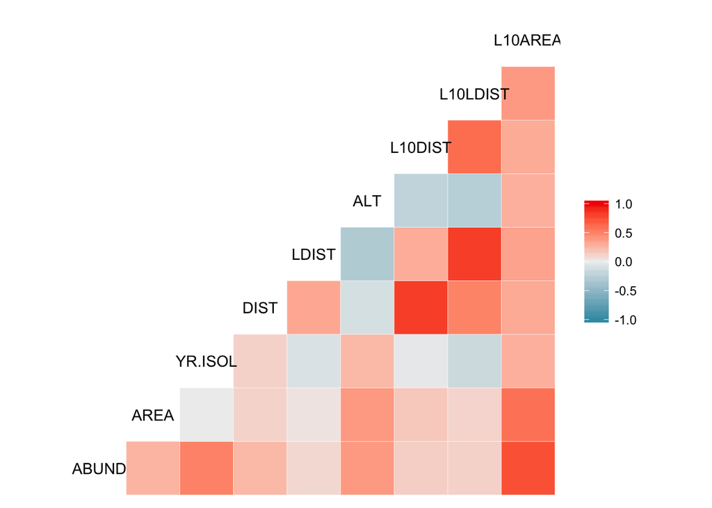

```r
# install.packages("GGally")

ggcorr(bird_abund[, 1:10])
```

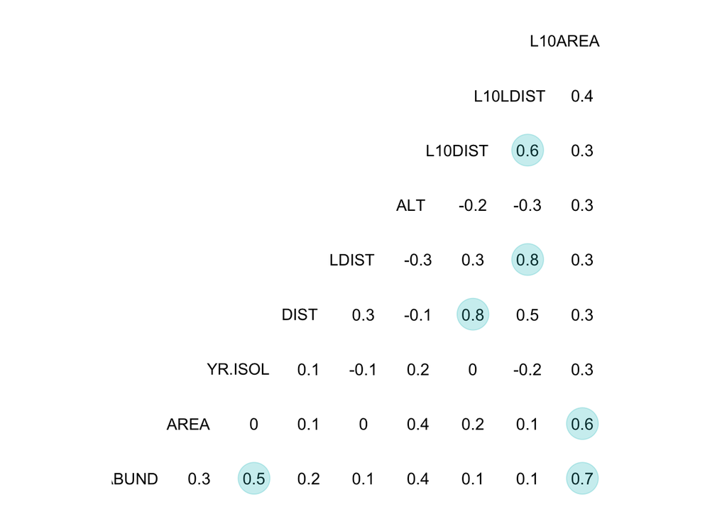

```r
ggcorr(bird_abund[, 1:10], geom = "blank", label = TRUE, hjust = 0.75) +
  geom_point(size = 10, aes(color = coefficient > 0, alpha = abs(coefficient) > 0.5)) +
  scale_alpha_manual(values = c("TRUE" = 0.25, "FALSE" = 0)) +
  guides(color = FALSE, alpha = FALSE)
```

We run the regression similarly to the simple regression model.

```r
bird_mod <- lm(ABUND ~ L10AREA + L10DIST + L10LDIST + GRAZE + ALT + YEAR_SINCE, data = bird_abund)

summary(bird_mod)
```

```
##
## Call:
## lm(formula = ABUND ~ L10AREA + L10DIST + L10LDIST + GRAZE + ALT +
##     YEAR_SINCE, data = bird_abund)
##
## Residuals:
##      Min       1Q   Median       3Q      Max
## -15.8992  -2.7245  -0.2772   2.7052  11.2811
##
## Coefficients:
##              Estimate Std. Error t value  Pr(>|t|)
## (Intercept)  11.29669    8.46090   1.335    0.1884
## L10AREA       6.83303    1.50330   4.545 0.0000397 ***
## L10DIST       0.33286    2.74778   0.121    0.9041
## L10LDIST      0.79765    2.13759   0.373    0.7107
## GRAZE2        0.52851    3.25221   0.163    0.8716
## GRAZE3        0.06601    2.95871   0.022    0.9823
## GRAZE4       -1.24877    3.19838  -0.390    0.6980
## GRAZE5      -12.47309    4.77827  -2.610    0.0122 *
## ALT           0.01070    0.02390   0.448    0.6565
## YEAR_SINCE    0.01277    0.05803   0.220    0.8267
## ---
## Signif. codes:  0 '***' 0.001 '**' 0.01 '*' 0.05 '.' 0.1 ' ' 1
##
## Residual standard error: 6.105 on 46 degrees of freedom
## Multiple R-squared:  0.7295, Adjusted R-squared:  0.6766
## F-statistic: 13.78 on 9 and 46 DF,  p-value: 2.115e-10
```

```r
anova(bird_mod)
```

```
## Analysis of Variance Table
##
## Response: ABUND
##            Df Sum Sq Mean Sq F value    Pr(>F)
## L10AREA     1 3471.0  3471.0 93.1303 1.247e-12 ***
## L10DIST     1   65.5    65.5  1.7568 0.1915648
## L10LDIST    1  136.5   136.5  3.6630 0.0618676 .
## GRAZE       4  938.6   234.6  6.2958 0.0003977 ***
## ALT         1   10.1    10.1  0.2718 0.6046450
## YEAR_SINCE  1    1.8     1.8  0.0485 0.8267495
## Residuals  46 1714.4    37.3
## ---
## Signif. codes:  0 '***' 0.001 '**' 0.01 '*' 0.05 '.' 0.1 ' ' 1
```

And now take a look at the prediction with the residuals. First we want to use the `augment()` function from the `broom` package to create the predictions.

```r
mod_pred <- augment(bird_mod)
glimpse(mod_pred)
```

```
## Observations: 56
## Variables: 14
## $ ABUND      <dbl> 5.3, 2.0, 1.5, 17.1, 13.8, 14.1, 3.8, 2.2, 3.3, 3.0...
## $ L10AREA    <dbl> -1.0000000, -0.3010300, -0.3010300, 0.0000000, 0.00...
## $ L10DIST    <dbl> 1.591065, 2.369216, 2.017033, 1.819544, 2.390935, 2...
## $ L10LDIST   <dbl> 1.591065, 2.369216, 2.492760, 1.819544, 2.390935, 2...
## $ GRAZE      <fctr> 2, 5, 5, 3, 5, 3, 5, 5, 4, 5, 3, 5, 2, 1, 5, 5, 3,...
## $ ALT        <int> 160, 60, 140, 160, 140, 130, 90, 60, 130, 130, 210,...
## $ YEAR_SINCE <dbl> 19, 67, 87, 21, 69, 22, 32, 67, 22, 87, 61, 97, 14,...
## $ .fitted    <dbl> 8.7455613, 0.9429609, 2.0357546, 15.3999285, 3.9059...
## $ .se.fit    <dbl> 3.248195, 2.317437, 2.166315, 2.065503, 2.074047, 2...
## $ .resid     <dbl> -3.4455613, 1.0570391, -0.5357546, 1.7000715, 9.894...
## $ .hat       <dbl> 0.2830886, 0.1440967, 0.1259162, 0.1144695, 0.11541...
## $ .sigma     <dbl> 6.142511, 6.170043, 6.171802, 6.166515, 5.969861, 6...
## $ .cooksd    <dbl> 0.0175448451, 0.0005896914, 0.0001269244, 0.0011320...
## $ .std.resid <dbl> -0.66657084, 0.18715342, -0.09386602, 0.29592694, 1...
```

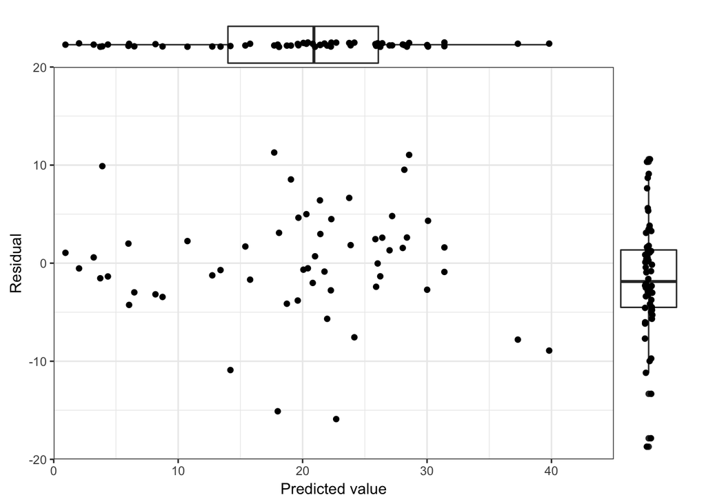

```r
scatter_with_box(xvar=".fitted",yvar=".resid", xlim=c(0,45), ylim=c(-20,20), xlabel ="Predicted value", ylabel = "Residual", data=mod_pred)
```